# Colorectal Cancer Detection Using Targeted Serum Metabolic Profiling

08/13/20

# Background

Data set from a study to identify biomarkers using metabolomics for early detection of colorectal cancer

Data set obtained from the Metabolomic Workbench website

Link:https://www.metabolomicsworkbench.org/data/DRCCMetadata.php?Mode=Study&StudyID=ST000284&StudyType=MS&ResultType=1

Collected 234 serum samples from 3 patient groups: 66 CRC, 76 polyp and 92 healthy

Identified 158 metabolites

Allows for statistical analysis, heatmap generation and data visualization

Focus on metabolites involved in glycolysis since previous literature has shown that changes in glucose metabolism have been observed in CRC cases as well as other types of tumors

# Import Data from Excel file

```r
library(readxl)
colon_test_excel<- read_excel("CRC raw data for SUR analysis_ updated with patient ID.xlsx")
```

Table with 234 observations (patient samples) and 124 variables (metabolites+extra information)

Table contains only the information from 113 metabolites that were detected reliably and some information regarding gender, cancer status, age etc.

# Explore the data

The raw values are very different between each metabolite

```r
#Get an idea of the data
summary(colon_test_excel)
```

```
##     Groups           Patient   ID   1-Methyladenosine (282.1 / 150.0)
##  Length:234         Min.   :  1.0   Min.   : 176266
##  Class :character   1st Qu.:107.2   1st Qu.: 357051
##  Mode  :character   Median :215.0   Median : 409936
##                     Mean   :250.0   Mean   : 428691
##                     3rd Qu.:414.5   3rd Qu.: 480385
##                     Max.   :598.0   Max.   :1523682
##  1-Methylhistamine (126.0 / 109.0) 2-Aminoadipate (160.1 / 116.0)
##  Min.   :14292                     Min.   :  66238
##  1st Qu.:25608                     1st Qu.: 158022
##  Median :30647                     Median : 194883
##  Mean   :31251                     Mean   : 238874
##  3rd Qu.:36628                     3rd Qu.: 264544
##  Max.   :59907                     Max.   :2666709
##  2'-Deoxyuridine (229.1 / 113.0) 3-Nitro-tyrosine (225.0 / 179.3)
##  Min.   : 7818                   Min.   : 44805
##  1st Qu.:10951                   1st Qu.: 73793
##  Median :12137                   Median : 85794
##  Mean   :12239                   Mean   : 87381
##  3rd Qu.:13335                   3rd Qu.: 96672
##  Max.   :18136                   Max.   :176516
##  4-Pyridoxic acid (182.1 / 138.0) 5-Hydroxytryptophan (221.0 / 134.0)
##  Min.   :292105                   Min.   : 60573
##  1st Qu.:347380                   1st Qu.: 74264
##  Median :362318                   Median : 78683
##  Mean   :363232                   Mean   : 79148
##  3rd Qu.:379803                   3rd Qu.: 83509
##  Max.   :454543                   Max.   :113915
##  Acetoacetate (101.0 / 57.0) Acetylcholine (146.1 / 87.0)
##  Min.   :      1             Min.   : 227140
##  1st Qu.: 187735             1st Qu.:1479511
##  Median : 451225             Median :1748082
##  Mean   : 821428             Mean   :1848066
##  3rd Qu.: 884363             3rd Qu.:2147908
##  Max.   :6202848             Max.   :3933867
##  Aconitate (173.0 / 129.0) Adenosine (268.1 / 136.0)
##  Min.   : 188913           Min.   :   2934
##  1st Qu.: 409954           1st Qu.:  14292
##  Median : 528739           Median :  18981
##  Mean   : 582019           Mean   :  88585
```

[output cut: 309 more lines]

```
##  Max.   :3167610            Max.   :154511               Max.   :88.00
##     Gender          Smoking condition  Drink   Alcohol?    Diagnosis
##  Length:234         Length:234         Length:234         Length:234
##  Class :character   Class :character   Class :character   Class :character
##  Mode  :character   Mode  :character   Mode  :character   Mode  :character
##
##
##
##     Stage           Height [cm]        Weight [kg]        BMI [kg/mÂ²]
##  Length:234         Length:234         Length:234         Length:234
##  Class :character   Class :character   Class :character   Class :character
##  Mode  :character   Mode  :character   Mode  :character   Mode  :character
##
##
##
```

# Explore the data/ Clean data

Identified Class: Tibble Dataframe

Changed missing values to NA

Changed Group names to CRC, Polyp and Healthy

Created subsets to use in statistical analysis later by selecting columns or using the filter command

```r
#Identify class
class(colon_test_excel)
```

```
## [1] "tbl_df"     "tbl"        "data.frame"
```

```r
#Change missing values to NA
colon_test_excel[colon_test_excel == "-" ] <- NA

#Change Group Names
colon_test_excel$Groups <- recode_factor(colon_test_excel$Groups, `C` = "CRC", `H` = "Healthy", 'P' = "Polyp")

#Create subsets to use for statistical analysis
crc_healthy <- colon_test_excel[1:158, ]
healthy_polyp <- colon_test_excel[67:234,]
crc_polyp <- filter(colon_test_excel, Groups %in% c('CRC', 'Polyp'))
```

# Heatmap

Created matrix

Calculated the z-score using scale() because the raw values are very different between columns

Confirmed that the z-score command worked by checking the mean and standard deviation (mean should be 0 and sd should be 1)

Created a subset and a heatmap for each group

Turned off row clustering so the order of metabolites stays the same and I can compare between groups

Arranged heatmap side by side to observe differences between groups

The heatmap allows us to see that there are differences in metabolite levels between groups as well as within groups

We need to explore the relationships between groups and metabolites more in depth

```r
test_matrixall <- as.matrix(colon_test_excel[,3:115], "numeric")
rowlistall <- colon_test_excel[,1]
rowlistall <- unlist(rowlistall)
rownames(test_matrixall)<- rowlistall
zscorematrix <-scale(test_matrixall, center = TRUE, scale = TRUE)

round(apply(zscorematrix [,1:10],2, mean, na.rm = TRUE))
```

```
##   1-Methyladenosine (282.1 / 150.0)   1-Methylhistamine (126.0 / 109.0)
##                                   0                                   0
##      2-Aminoadipate (160.1 / 116.0)     2'-Deoxyuridine (229.1 / 113.0)
##                                   0                                   0
##    3-Nitro-tyrosine (225.0 / 179.3)    4-Pyridoxic acid (182.1 / 138.0)
##                                   0                                   0
## 5-Hydroxytryptophan (221.0 / 134.0)         Acetoacetate (101.0 / 57.0)
##                                   0                                   0
##        Acetylcholine (146.1 / 87.0)           Aconitate (173.0 / 129.0)
##                                   0                                   0
```

```r
round(apply(zscorematrix [,1:10],2, sd, na.rm = TRUE))
```

```
##   1-Methyladenosine (282.1 / 150.0)   1-Methylhistamine (126.0 / 109.0)
##                                   1                                   1
##      2-Aminoadipate (160.1 / 116.0)     2'-Deoxyuridine (229.1 / 113.0)
##                                   1                                   1
##    3-Nitro-tyrosine (225.0 / 179.3)    4-Pyridoxic acid (182.1 / 138.0)
##                                   1                                   1
## 5-Hydroxytryptophan (221.0 / 134.0)         Acetoacetate (101.0 / 57.0)
##                                   1                                   1
##        Acetylcholine (146.1 / 87.0)           Aconitate (173.0 / 129.0)
##                                   1                                   1
```

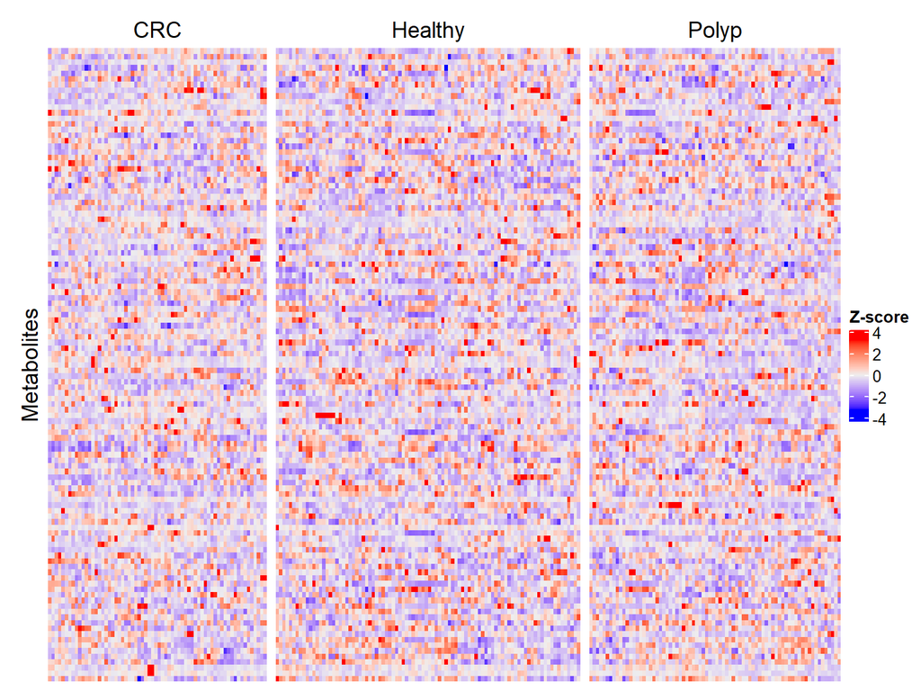

```r
CRC_matrixall <- zscorematrix[1:66,]
Healthy_matrixall <- zscorematrix[67:158,]
Polyp_matrixall <- zscorematrix[159:234,]

H1 <- Heatmap(scale(t(CRC_matrixall)), column_title = "CRC", row_title = "Metabolites",cluster_rows = FALSE, clustering_method_rows = "complete", show_row_names = FALSE, show_column_names = FALSE, show_column_dend = FALSE, show_heatmap_legend = FALSE)

H2 <- Heatmap(scale(t(Healthy_matrixall)), column_title = "Healthy", cluster_rows = FALSE, clustering_method_rows = "complete", show_row_names = FALSE, show_column_names = FALSE, show_column_dend = FALSE, show_heatmap_legend = FALSE)

H3 <- Heatmap(scale(t(Polyp_matrixall)), column_title = "Polyp",cluster_rows = FALSE, clustering_method_rows = "complete", show_row_names = FALSE, show_column_names = FALSE, show_column_dend = FALSE, name = 'Z-score')

H1+H2+H3
```

# Statistical Analysis

Checked data distribution using histograms

Data is not normally distributed so we need to use a non parametric test

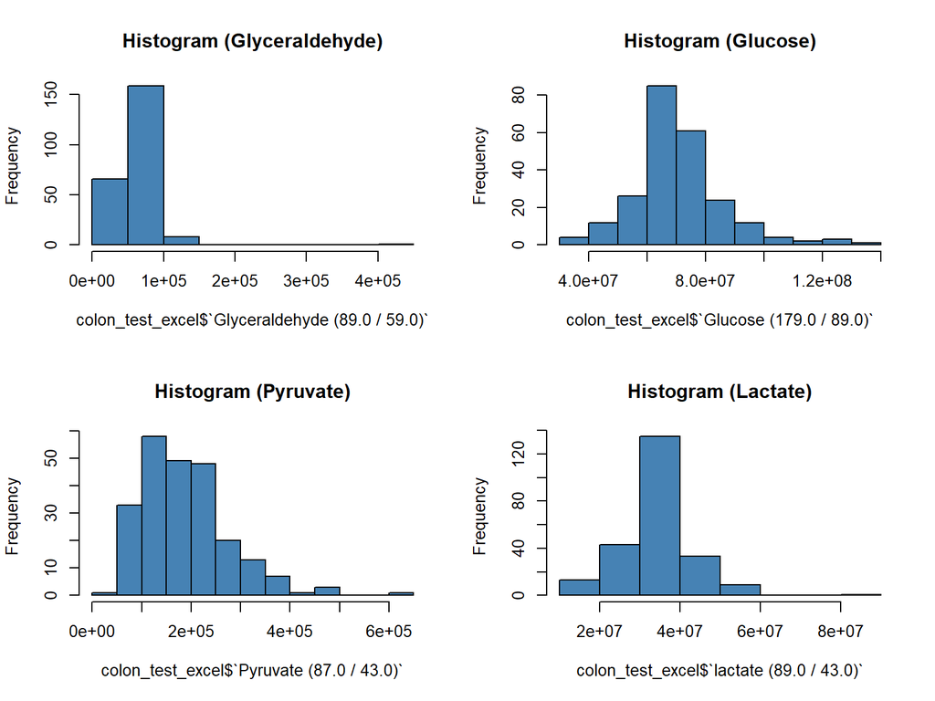

```r
#Check data distribution
par(mfrow=c(2,2))
hist(colon_test_excel$`Glyceraldehyde (89.0 / 59.0)`, main="Histogram (Glyceraldehyde)", col = 'steelblue')
hist(colon_test_excel$`Glucose (179.0 / 89.0)`, main="Histogram (Glucose)", col = 'steelblue')
hist(colon_test_excel$`Pyruvate (87.0 / 43.0)`, main="Histogram (Pyruvate)", col = 'steelblue')
hist(colon_test_excel$`lactate (89.0 / 43.0)`, main="Histogram (Lactate)", col = 'steelblue')
```

# Statistical Analysis

Since I have 3 groups I thought I should do a Kruskal-Wallis test with a pairwise comparison

However, on the paper they did Mann Whitney U tests which only looks at 2 groups at a time

I tried both tests and I noticed that I got significant p-values between the same groups even though the p-value was not always the same

I decided to move forward with the Mann Whitney test because I care about differences between the pairs of groups

# Statistical Analysis (Mann-Whitney U Test)

Compare CRC and Healthy

```r
#Compare CRC and healthy
wilcox.test(crc_healthy$`Glyceraldehyde (89.0 / 59.0)` ~ crc_healthy$Groups, paired = FALSE)
```

```
##
##  Wilcoxon rank sum test with continuity correction
##
## data:  crc_healthy$`Glyceraldehyde (89.0 / 59.0)` by crc_healthy$Groups
## W = 4263, p-value = 1.532e-05
## alternative hypothesis: true location shift is not equal to 0
```

Compare Healthy and Polyp

```r
wilcox.test(healthy_polyp$`Glyceraldehyde (89.0 / 59.0)` ~ healthy_polyp$Groups, paired = FALSE)
```

```
##
##  Wilcoxon rank sum test with continuity correction
##
## data:  healthy_polyp$`Glyceraldehyde (89.0 / 59.0)` by healthy_polyp$Groups
## W = 3897, p-value = 0.2019
## alternative hypothesis: true location shift is not equal to 0
```

Compare CRC and Polyp

```r
wilcox.test(crc_polyp$`Glyceraldehyde (89.0 / 59.0)` ~ crc_polyp$Groups, paired = FALSE)
```

```
##
##  Wilcoxon rank sum test with continuity correction
##
## data:  crc_polyp$`Glyceraldehyde (89.0 / 59.0)` by crc_polyp$Groups
## W = 3775, p-value = 2.216e-07
## alternative hypothesis: true location shift is not equal to 0
```

# Statistical Analysis (Mann-Whitney U Test)

Compare CRC and Healthy

```r
#Compare CRC and healthy
wilcox.test(crc_healthy$`Glucose (179.0 / 89.0)` ~ crc_healthy$Groups, paired = FALSE)
```

```
##
##  Wilcoxon rank sum test with continuity correction
##
## data:  crc_healthy$`Glucose (179.0 / 89.0)` by crc_healthy$Groups
## W = 3666, p-value = 0.02646
## alternative hypothesis: true location shift is not equal to 0
```

Compare Healthy and Polyp

```r
wilcox.test(healthy_polyp$`Glucose (179.0 / 89.0)` ~ healthy_polyp$Groups, paired = FALSE)
```

```
##
##  Wilcoxon rank sum test with continuity correction
##
## data:  healthy_polyp$`Glucose (179.0 / 89.0)` by healthy_polyp$Groups
## W = 3015, p-value = 0.1257
## alternative hypothesis: true location shift is not equal to 0
```

Compare CRC and Polyp

```r
wilcox.test(crc_polyp$`Glucose (179.0 / 89.0)` ~ crc_polyp$Groups, paired = FALSE)
```

```
##
##  Wilcoxon rank sum test with continuity correction
##
## data:  crc_polyp$`Glucose (179.0 / 89.0)` by crc_polyp$Groups
## W = 2666, p-value = 0.5194
## alternative hypothesis: true location shift is not equal to 0
```

# Statistical Analysis (Mann-Whitney U Test)

Compare CRC and Healthy

```r
#Compare CRC and healthy
wilcox.test(crc_healthy$`Pyruvate (87.0 / 43.0)` ~ crc_healthy$Groups, paired = FALSE)
```

```
##
##  Wilcoxon rank sum test with continuity correction
##
## data:  crc_healthy$`Pyruvate (87.0 / 43.0)` by crc_healthy$Groups
## W = 3649, p-value = 0.03082
## alternative hypothesis: true location shift is not equal to 0
```

Compare Healthy and Polyp

```r
wilcox.test(healthy_polyp$`Pyruvate (87.0 / 43.0)` ~ healthy_polyp$Groups, paired = FALSE)
```

```
##
##  Wilcoxon rank sum test with continuity correction
##
## data:  healthy_polyp$`Pyruvate (87.0 / 43.0)` by healthy_polyp$Groups
## W = 3096, p-value = 0.203
## alternative hypothesis: true location shift is not equal to 0
```

Compare CRC and Polyp

```r
wilcox.test(crc_polyp$`Pyruvate (87.0 / 43.0)` ~ crc_polyp$Groups, paired = FALSE)
```

```
##
##  Wilcoxon rank sum test with continuity correction
##
## data:  crc_polyp$`Pyruvate (87.0 / 43.0)` by crc_polyp$Groups
## W = 2699, p-value = 0.4359
## alternative hypothesis: true location shift is not equal to 0
```

# Statistical Analysis (Mann-Whitney U Test)

Compare CRC and Healthy

```r
#Compare CRC and healthy
wilcox.test(crc_healthy$`lactate (89.0 / 43.0)` ~ crc_healthy$Groups, paired = FALSE)
```

```
##
##  Wilcoxon rank sum test with continuity correction
##
## data:  crc_healthy$`lactate (89.0 / 43.0)` by crc_healthy$Groups
## W = 3621, p-value = 0.03933
## alternative hypothesis: true location shift is not equal to 0
```

Compare Healthy and Polyp

```r
wilcox.test(healthy_polyp$`lactate (89.0 / 43.0)` ~ healthy_polyp$Groups, paired = FALSE)
```

```
##
##  Wilcoxon rank sum test with continuity correction
##
## data:  healthy_polyp$`lactate (89.0 / 43.0)` by healthy_polyp$Groups
## W = 3078, p-value = 0.1834
## alternative hypothesis: true location shift is not equal to 0
```

Compare CRC and Polyp

```r
wilcox.test(crc_polyp$`lactate (89.0 / 43.0)` ~ crc_polyp$Groups, paired = FALSE)
```

```
##
##  Wilcoxon rank sum test with continuity correction
##
## data:  crc_polyp$`lactate (89.0 / 43.0)` by crc_polyp$Groups
## W = 2662, p-value = 0.5301
## alternative hypothesis: true location shift is not equal to 0
```

# Summary of Statistical Analysis

Glyceraldehyde: Statistically significant difference between CRC/Healthy and CRC/Polyp

Glucose: Statistically significant difference between CRC/Healthy

Pyruvate: Statistically significant difference between CRC/Healthy

Lactate: Statistically significant difference between CRC/Healthy

# Data Visualization

Plot mean to visualize difference

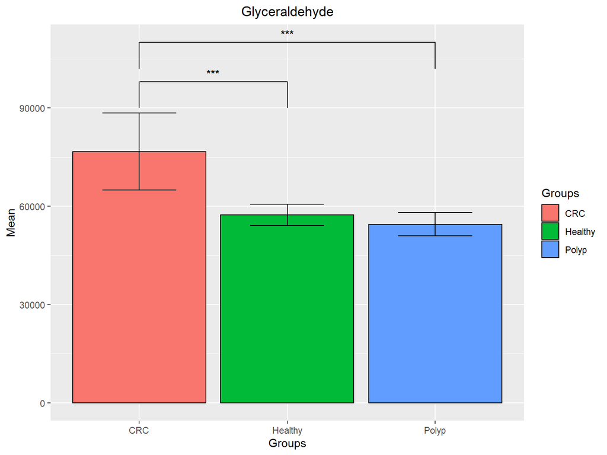

```r
#Bar graph
bar1 <- ggplot(colon_test_excel, aes(x = Groups, y = `Glyceraldehyde (89.0 / 59.0)`, fill=Groups)) + stat_summary(fun = mean, geom="bar", color = "black") + stat_summary(fun.data = mean_cl_normal, geom = "errorbar", width = .5)+ ggtitle("Glyceraldehyde") + ylab("Mean") +   theme(plot.title = element_text(hjust = 0.5)) + geom_signif(comparisons = list(c("CRC", "Healthy")), annotations="***", y_position = 98000, tip_length = 0.02) + geom_signif(comparisons = list(c("CRC", "Polyp")), annotations="***", y_position = 110000, tip_length = 0.02)

bar2 <-ggplot(colon_test_excel, aes(x = Groups, y = `Glucose (179.0 / 89.0)`, fill=Groups)) + stat_summary(fun = mean, geom="bar", color = "black") + stat_summary(fun.data = mean_cl_normal, geom = "errorbar", width = .5)+ ggtitle("Glucose") + ylab("Mean") + theme(plot.title = element_text(hjust = 0.5)) + geom_signif(comparisons = list(c("CRC", "Healthy")), annotations="*", y_position = 8e+07, tip_length = 0.02)

bar3 <-ggplot(colon_test_excel, aes(x = Groups, y = `Pyruvate (87.0 / 43.0)`, fill=Groups)) + stat_summary(fun = mean, geom="bar", color = "black") + stat_summary(fun.data = mean_cl_normal, geom = "errorbar", width = .5)+ ggtitle("Pyruvate") + ylab("Mean") + theme(plot.title = element_text(hjust = 0.5)) + geom_signif(comparisons = list(c("CRC", "Healthy")), annotations="*", y_position = 240000, tip_length = 0.02)

bar4 <-ggplot(colon_test_excel, aes(x = Groups, y = `lactate (89.0 / 43.0)`, fill=Groups)) + stat_summary(fun = mean, geom="bar", color = "black") + stat_summary(fun.data = mean_cl_normal, geom = "errorbar", width = .5)+ ggtitle("Lactate") + ylab("Mean") +   theme(plot.title = element_text(hjust = 0.5)) + geom_signif(comparisons = list(c("CRC", "Healthy")), annotations="*", y_position = 4.2e+07, tip_length = 0.02)

#grid.arrange(bar1, bar2, bar3, bar4, ncol=2)

bar1
```

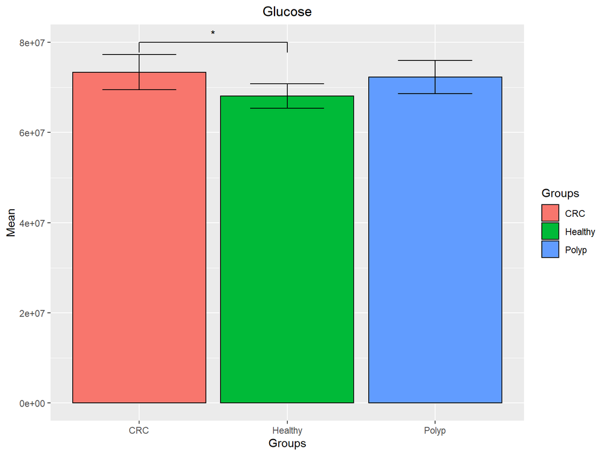

```r
bar2
```

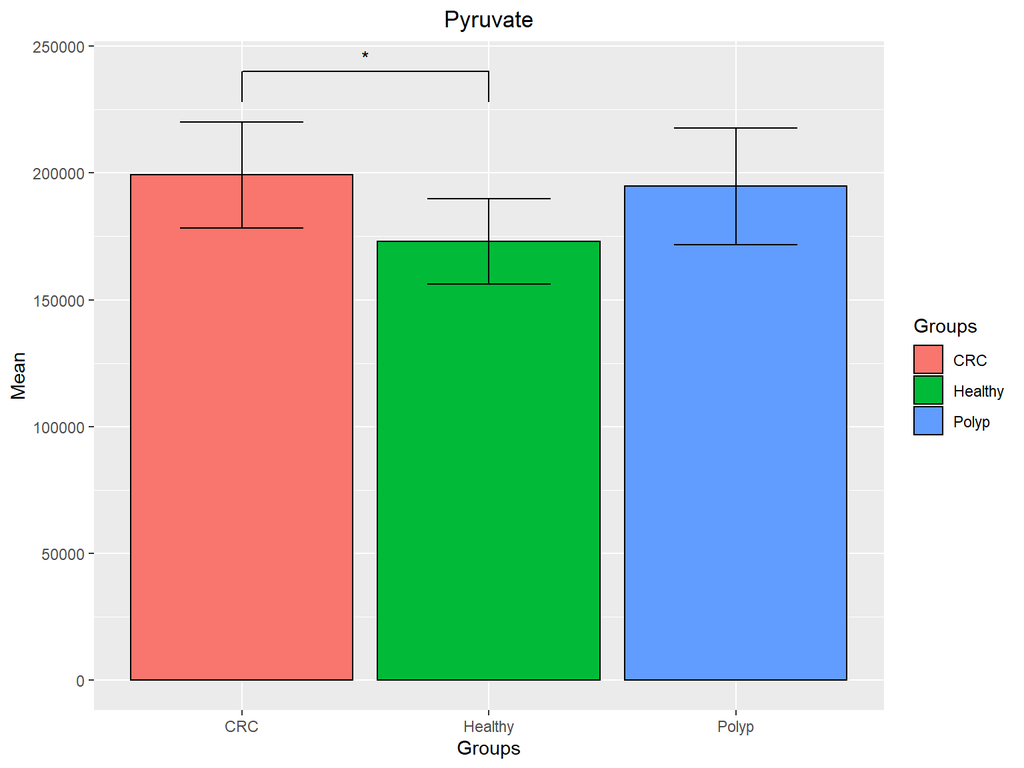

```r
bar3
```

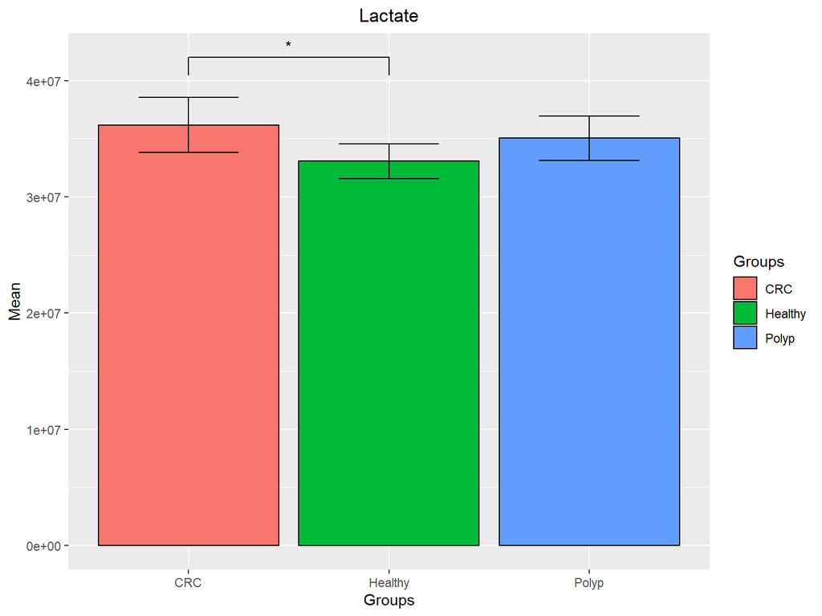

```r
bar4
```

# Logistic Regression

Prepared 2 models for the CRC and Healthy groups

Fit_model_1: glucose as predictor variable

Fit_model_2: glucose, lactate and pyruvate as predictor variables

Comparison by AIC shows that Fit2_model_2 is a worse model

cooks.distance command does not show that there are individual outliers that largely influence our data

```r
#Model 1
fit_model_1 <- glm(Groups ~ `Glucose (179.0 / 89.0)`, data=crc_healthy, family="binomial")

summary(fit_model_1)
```

```
##
## Call:
## glm(formula = Groups ~ `Glucose (179.0 / 89.0)`, family = "binomial",
##     data = crc_healthy)
##
## Deviance Residuals:
##    Min      1Q  Median      3Q     Max
## -1.778  -1.307   0.894   1.031   1.568
##
## Coefficients:
##                            Estimate Std. Error z value Pr(>|z|)
## (Intercept)               2.174e+00  8.574e-01   2.536   0.0112 *
## `Glucose (179.0 / 89.0)` -2.608e-08  1.189e-08  -2.194   0.0282 *
## ---
## Signif. codes:  0 '***' 0.001 '**' 0.01 '*' 0.05 '.' 0.1 ' ' 1
##
## (Dispersion parameter for binomial family taken to be 1)
##
##     Null deviance: 214.74  on 157  degrees of freedom
## Residual deviance: 209.56  on 156  degrees of freedom
## AIC: 213.56
##
## Number of Fisher Scoring iterations: 4
```

```r
oddsRatio <- exp(fit_model_1$coefficients)
oddsRatio
```

```
##              (Intercept) `Glucose (179.0 / 89.0)`
##                  8.79399                  1.00000
```

```r
exp(confint(fit_model_1))
```

```
##                              2.5 %   97.5 %
## (Intercept)              1.7321195 51.34149
## `Glucose (179.0 / 89.0)` 0.9999999  1.00000
```

# Logistic Regression

```r
#Model 2
fit_model_2 <- glm(Groups ~ `Glucose (179.0 / 89.0)` + `lactate (89.0 / 43.0)` +`Pyruvate (87.0 / 43.0)`, data=crc_healthy, family="binomial")

summary(fit_model_2)
```

```
##
## Call:
## glm(formula = Groups ~ `Glucose (179.0 / 89.0)` + `lactate (89.0 / 43.0)` +
##     `Pyruvate (87.0 / 43.0)`, family = "binomial", data = crc_healthy)
##
## Deviance Residuals:
##     Min       1Q   Median       3Q      Max
## -1.7456  -1.2715   0.8845   1.0203   1.5837
##
## Coefficients:
##                            Estimate Std. Error z value Pr(>|z|)
## (Intercept)               2.080e+00  8.695e-01   2.392   0.0168 *
## `Glucose (179.0 / 89.0)` -9.305e-09  2.391e-08  -0.389   0.6972
## `lactate (89.0 / 43.0)`  -2.345e-08  4.381e-08  -0.535   0.5926
## `Pyruvate (87.0 / 43.0)` -1.508e-06  2.549e-06  -0.592   0.5542
## ---
## Signif. codes:  0 '***' 0.001 '**' 0.01 '*' 0.05 '.' 0.1 ' ' 1
##
## (Dispersion parameter for binomial family taken to be 1)
##
##     Null deviance: 214.74  on 157  degrees of freedom
## Residual deviance: 208.68  on 154  degrees of freedom
## AIC: 216.68
##
## Number of Fisher Scoring iterations: 4
```

```r
#Comparison using the Akaike Information Criteria
AIC(fit_model_1, fit_model_2)
```

```
##             df      AIC
## fit_model_1  2 213.5602
## fit_model_2  4 216.6808
```

```r
which(cooks.distance(fit_model_1)>10)
```

```
## named integer(0)
```

```r
which(cooks.distance(fit_model_2)>10)
```

```
## named integer(0)
```

# Summary and Future Direction

The dataframe contained a lot of information so I had to focus on a subset

Higher mean levels of glucose, pyruvate and lactate were observed in CRC patients compared to healthy patients

Interestingly, a regression model with glucose, lactate and pyruvate behaved worse than a model containing only glucose

For the future, I would like to analyze a bigger portion of the data and do PLS Discriminant Analysis to identify metabolites that can distinguish between healthy and CRC patients

I would also like to explore if there is a relationship between the different cancer stages and different levels of metabolites

# Citations

Zhu, J., et al. (2014). “Colorectal Cancer Detection Using Targeted Serum Metabolic Profiling.” Journal of Proteome Research 13(9): 4120-4130.